# Patrón de cuotas para casa de apuestas en base al análisis del desempeño futbolístico de 5 ligas europeas entre 2015 y 2021

# 1. Importancia

El fútbol es, dentro de la industria del deporte, posiblemente la más importante y más popular entre el público a nivel mundial. La información concerniente o relacionada a este ámbito es de suma importancia y valiosa, no solo para los equipos dentro de las ligas competitivas, sino también para agentes externos como lo son las casas de apuestas. Estos negocios, particularmente, basan su modelo financiero en análisis estadísticos para cada encuentro, de esta forma determinan la cuota que deben cobrar a sus jugadores y así no tener pérdidas. Para esta industria, el valor de la información analítica de los equipos de fútbol es bastante alta porque de eso depende el éxito de su negocio, deben conocer los factores, patrones y características que determinan el desempeño de un equipo y sus jugadores. El presente estudio analiza 5 ligas europeas para determinar el modelo de negocio que debe adaptar una casa de apuestas para lograr tener éxito. Para llegar a dicho análisis se tomarán los años dentro del rango 2015 a 2021 bajo las variables de goles, asistencias, disparos al arco, victorias de local y victorias de visitantes.

## 1.1. Objetivos

### 1.1.1. Objetivo principal:

- Determinar el modelo de negocio para el éxito de una casa de apuestas en base al análisis del desempeño individual y colectivo de los equipos pertenecientes a cinco ligas europeas de fútbol entre el 2016 y 2020.

### 1.1.2. Objetivos específicos:

- Evaluar la evolución entorno a los goles anotados de cada liga
- Comparar la frecuencia de disparos al arco y goles anotados de uno de los jugadores más determinantes de las 5 ligas entre el 2015 y 2021
- Clasificar las ligas y su nivel de competitividad
- Clasificar a los jugadores de todas las ligas según goles anotados
- Clasificar los equipos de las 5 ligas en base a nivel ofensivo——–
- Determinar los equipos con más victorias de locales y visitantes———-
- Determinar la liga más ofensiva en la temporada 2015——-
- Determinar la temporada con más goles generados———
- Determinar el equipo más representativos de cada liga respecto a los goles que anota——–
- Determinar los equipos escaleras de cada división
- Determinar la cuota a cobrar en encuentros aleatorios

# 2. Planificación

A lo largo del curso se tienen programados diversos entregables y presentaciones, para lo cual contamos con herramientas como asesorías, libros, sesiones de clase y material adicional. De forma complementaria desarrollamos el siguiente Diagrama de Gantt con las fechas asignadas para las entregas y así cumplir con los objetivos del trabajo.

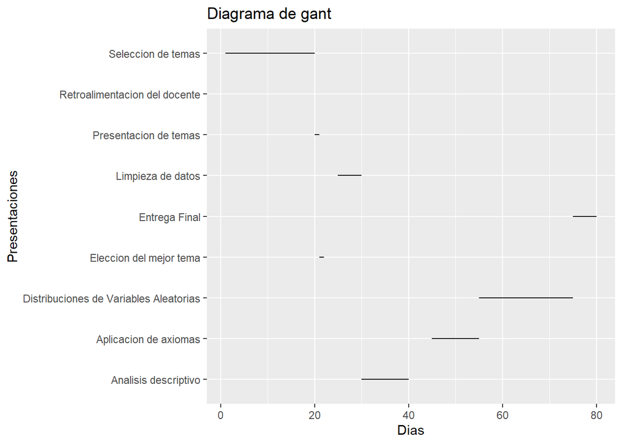

```r
if(!require(ggplot2))
library(ggplot2)
data <- data.frame(Presentaciones = c('Seleccion de temas', 'Presentacion de temas', 'Eleccion del mejor tema', 'Retroalimentacion del docente', 'Limpieza de datos', 'Analisis descriptivo', 'Aplicacion de axiomas', 'Distribuciones de Variables Aleatorias','Entrega Final'),
Dias = c(1, 20, 21, 35, 25, 30, 45,55,75),
dias_fin = c(20, 21, 22, 35, 30, 40, 55,75,80)
)

ggplot(data, aes(x=Dias, xend=dias_fin, y=Presentaciones, yend=Presentaciones)) +
  geom_segment()+labs(title="Diagrama de gant")
```

# 3. Datos

Para este proyecto se utilizará una base de datos pública y confiable, obtenida de https://www.kaggle.com/datasets/technika148/football-database?resource=download&select=games.csv, una web dedicada al rubro de la ciencia de datos la cual registra la información requerida para este estudio. Esta base de datos se encuentra en formato csv y es de descarga libre.

# 4. Clasificación de variables

## 4.1. Variables Categóricas

### 4.1.1. Variables nominales

| Variable | Definicion |
| --- | --- |
| playerID | Código del jugador |
| gameID | Código del juego |
| playerID | Código del jugador |
| substituteIn | Código del jugador entrante al hacer un cambio |
| substituteOut | Código del jugador saliente al hacer un cambio |
| leagueID | Código de la liga |
| teamID | Código del equipo |
| shooterID | Código del jugador que realiza el disparo |
| assisterID | Código del jugador que realiza la asistencia |
| player | Nombre del jugador |
| team | Nombre del equipo |
| league | Nombre de la liga |
| understatNotation | Sigla del nombre de la liga |
| position | Posición del jugador |
| situation | Situación en la que se da el disparo (corner o juego libre) |
| lastAction | Acción anterior al disparo |
| shotType | Parte del cuerpo con la que el jugador realiza el disparo |
| shotResult | Resultado del disparo |

### 4.1.2. Variables ordinales

| Variable | Definicion |
| --- | --- |
| season | Temporada en la que se jugó el partido |

## 4.2. Variables Numéricas

### 4.2.1. Variables continuas

| Variable | Definicion |
| --- | --- |
| date | Fecha del partido |
| ppda | Número de pases enemigos completados a través de la línea de defensa |
| xAssists | Probabilidad de un pase en conventirse en gol |
| xGoals | Probabilidad de convertir un disparo en gol |
| xGoalsChain | Probabilidad de convertir un disparo en gol en función a la posición del jugador |
| xGoalsBuildup | Probabilidad de convertir un disparo o pase clave en gol |
| xGoal | Probabilidad de convertir en gol un disparo de un jugador |

### 4.2.2. Variables discretas

| Variable | Definicion |
| --- | --- |
| time | tiempo de participación de un jugador en el partido |
| deep | indica la distancia entre un jugador y la línea de meta |
| player goals | número de goles de un jugador en un juego |
| player ownGoals | número de autogoles de un jugador en un juego |
| player shots | número de disparos de un jugador en un juego |
| player assists | número de asistencias de un jugador en un juego |
| keyPasses | número de pases clave de un jugador en un juego |
| player yellowCard | número de tarjetas amarillas de un jugador en un juego |
| player redCard | número de tarjetas rojas de un jugador en un juego |
| minute | minuto en el que un jugador realiza un disparo |
| team goals | número de goles del equipo en el encuentro |
| team shots | número de disparos del equipo en el encuentro |
| shotsOnTarget | número de disparos al arco del equipo en el encuentro |
| fouls | número de faltas cometidas por el equipo en el encuentro |
| corners | número de saques de esquina del equipo en el encuentro |
| yellowCards | número de tarjetas amarillas del equipo en el encuentro |
| redCards | número de tarjetas rojas del equipo en el encuentro |

# 5. Limpieza de datos

Para la realización de este proyecto contamos con una base de datos estructurada en distintos archivos los cuales se relacionan entre ellos, siendo que algunos trabajan bajo los argumentos “ID” y otros los decodifican.

Primero realizamos la lectura de los archivos con los que trabajaremos a lo largo del proyecto:

```r
library(scales)
library(readr)
library(tidyverse)
library(dplyr)
library(repmis)
library(rriskDistributions)
```

```r
library(boxplotdbl)
library(ggplot2)
```

```r
juegos <- read.csv("games.csv")
apariciones <- read.csv("appearances.csv")
ligas <- read.csv("leagues.csv")
jugadores <- read.csv("players.csv")
disparos <- read.csv("shots.csv")
equipos <- read.csv("teams.csv")
estadistica_equipos <- read.csv("teamstats.csv")
```

Utilizando la función **`nrow()`** podremos contar la cantidad de observaciones (filas) correspondientes a los 4 data frames de nuestra base de datos y utilizando la función **`ncol()`** podremos contar la cantidad de variables (columnas).

```r
n_observaciones <- nrow(apariciones) + nrow(juegos) + nrow (disparos) + nrow(estadistica_equipos)
n_variables <- ncol(apariciones) + ncol(juegos) + ncol(disparos) + ncol(estadistica_equipos)
```

De esta forma logramos calcular que existe en nuestra base de datos **719096 observaciones observaciones y 80 variables.**

Como se mencionó al inicio, nuestra base de datos trabaja de forma en la que cada archivo está relacionado con el otro, en el cual los nombres de jugadores y las ligas se mencionan bajo ID’s. Para poder trabajar con esta información, es necesario adaptar los archivos de forma en la que se ajusten y faciliten el estudio:

- *Data frame* con los datos correspondientes a las apariciones de cada jugador en todos los partidos.

```r
apariciones <- jugadores %>%
  right_join(apariciones,by="playerID") %>%
  left_join(ligas,by="leagueID") %>%
  left_join(juegos %>%
              select(gameID,season),by="gameID")

apariciones %>% rename(ID = playerID, player = name.x, league = name.y, league_notation = understatNotation) ->
n_apariciones
remove(apariciones)
apariciones <- distinct(n_apariciones)
rm(n_apariciones)
```

- *Data frame* con los datos correspondientes a los partidos jugados por cada equipo.

```r
estadistica_equipos <- equipos %>% right_join(estadistica_equipos,by= "teamID") %>%
  right_join (apariciones %>%
                select(league,gameID),by="gameID") %>%
  rename(team=name) %>%
  distinct
equipos_ord <- equipos[order(equipos$teamID),]
goles_totales <- by(estadistica_equipos$goals , estadistica_equipos$teamID, sum)
equipos <- mutate(equipos, goles_totales)
equipos$goles_totales = as.numeric(equipos$goles_totales)
estadistica_equipos %>% mutate(result =
        ifelse(result == "W", 3,
        ifelse(result == "D", 1,ifelse(result == "L", 0 ,result)))) -> estadistica_equipos

estadistica_equipos$result = as.numeric(estadistica_equipos$result)
goles_totales_league <- by(estadistica_equipos$goals , estadistica_equipos$league, sum)
ligas <- mutate(ligas, goles_totales_league)
goles_totales_league <- by(estadistica_equipos$goals , estadistica_equipos$teamID, sum)
ligas$goles_totales_league = as.numeric(ligas$goles_totales_league)
estadistica_equipos<- estadistica_equipos %>%filter(season>2015)
head(estadistica_equipos)
```

|  | teamID | team | gameID | season | date | location | goals | xGoals | shots | shotsOnTarget | deep | ppda | fouls | corners | yellowCards | redCards | result | league |
| --- | --- | --- | --- | --- | --- | --- | --- | --- | --- | --- | --- | --- | --- | --- | --- | --- | --- | --- |
| 1 | 71 | Aston Villa | 11649 | 2019 | 2019-08-10 17:30:00 | a | 1 | 0.639599 | 7 | 4 | 2 | 13.4211 | 9 | 0 | 0 | 0 | 0 | Premier League |
| 2 | 71 | Aston Villa | 11654 | 2019 | 2019-08-17 15:00:00 | h | 1 | 1.650690 | 22 | 7 | 12 | 13.0000 | 10 | 10 | 0 | 0 | 0 | Premier League |
| 3 | 71 | Aston Villa | 11663 | 2019 | 2019-08-23 20:00:00 | h | 2 | 0.855926 | 7 | 3 | 6 | 13.2500 | 10 | 0 | 2 | 0 | 3 | Premier League |
| 4 | 71 | Aston Villa | 11676 | 2019 | 2019-08-31 15:00:00 | a | 0 | 0.303540 | 10 | 2 | 5 | 9.0400 | 16 | 2 | 4 | 1 | 0 | Premier League |
| 5 | 71 | Aston Villa | 11692 | 2019 | 2019-09-16 19:00:00 | h | 0 | 1.405020 | 10 | 5 | 4 | 9.6818 | 13 | 2 | 2 | 0 | 1 | Premier League |
| 6 | 71 | Aston Villa | 11702 | 2019 | 2019-09-22 15:30:00 | a | 2 | 1.715460 | 14 | 9 | 8 | 11.0000 | 15 | 4 | 1 | 0 | 0 | Premier League |

- *Data frame* con los datos correspondientes a los disparos realizados por cada jugador en cada partido.

```r
disparos <- disparos %>% rename(playerID = shooterID)
disparos <- jugadores %>% inner_join(disparos,by="playerID") %>% inner_join(juegos %>% select(gameID,season),by="gameID") %>% inner_join (apariciones %>% select(league,gameID),by="gameID") %>% distinct
disparos <- disparos %>% rename(player=name)
```

Para complementar, seleccionamos las columnas que contienen las variables que necesitamos de cada *data frame* y descartamos las que no.

Se realizo la siguiente limpieza para obtener el número de goles por liga:

```r
apariciones %>% filter(league=="Premier League")%>%group_by(player) %>% summarise(goal_avg = mean(goals), goals_median = median (goals), goals_sd = sd(goals), max_goals = max(goals)) %>% arrange(desc(goal_avg)) %>% filter(goal_avg != 1) -> n_goalPremierLeague

apariciones %>% filter(league=="Serie A")%>%group_by(player) %>% summarise(goal_avg = mean(goals), goals_median = median (goals), goals_sd = sd(goals), max_goals = max(goals)) %>% arrange(desc(goal_avg)) %>% filter(goal_avg != 1) -> n_goalSerieA

apariciones %>% filter(league=="La Liga")%>%group_by(player) %>% summarise(goal_avg = mean(goals), goals_median = median (goals), goals_sd = sd(goals), max_goals = max(goals)) %>% arrange(desc(goal_avg)) %>% filter(goal_avg != 1) -> n_goalLaLiga

apariciones %>% filter(league=="Ligue 1")%>%group_by(player) %>% summarise(goal_avg = mean(goals), goals_median = median (goals), goals_sd = sd(goals), max_goals = max(goals)) %>% arrange(desc(goal_avg)) %>% filter(goal_avg != 1) -> n_goalLigue1

apariciones %>% filter(league=="Bundesliga")%>%group_by(player) %>% summarise(goal_avg = mean(goals), goals_median = median (goals), goals_sd = sd(goals), max_goals = max(goals)) %>% arrange(desc(goal_avg)) %>% filter(goal_avg != 1) -> n_goalBundesliga
```

Se realizo el filtrado para la obtencion de las tarjetas amarillas por liga:

```r
yelow_premierleague <-estadistica_equipos %>% filter(league=="Premier League") %>% group_by(team)%>%summarise(ycards_avg = mean (yellowCards), ycards_median = median(yellowCards), ycards_cv = sd(yellowCards)/mean(yellowCards), max_ycards = max(yellowCards), total_ycards = sum(yellowCards)) %>% arrange(desc(ycards_avg))

yelow_SerieA <-estadistica_equipos %>% filter(league=="Serie A") %>% group_by(team)%>%summarise(ycards_avg = mean (yellowCards), ycards_median = median(yellowCards), ycards_cv = sd(yellowCards)/mean(yellowCards), max_ycards = max(yellowCards), total_ycards = sum(yellowCards)) %>% arrange(desc(ycards_avg))

yelow_LaLiga <-estadistica_equipos %>% filter(league=="La Liga") %>% group_by(team)%>%summarise(ycards_avg = mean (yellowCards), ycards_median = median(yellowCards), ycards_cv = sd(yellowCards)/mean(yellowCards), max_ycards = max(yellowCards), total_ycards = sum(yellowCards)) %>% arrange(desc(ycards_avg))

yelow_Ligue1 <-estadistica_equipos %>% filter(league=="Ligue 1") %>% group_by(team)%>%summarise(ycards_avg = mean (yellowCards), ycards_median = median(yellowCards), ycards_cv = sd(yellowCards)/mean(yellowCards), max_ycards = max(yellowCards), total_ycards = sum(yellowCards)) %>% arrange(desc(ycards_avg))

yelow_Bundesliga <-estadistica_equipos %>% filter(league=="Bundesliga") %>% group_by(team)%>%summarise(ycards_avg = mean (yellowCards), ycards_median = median(yellowCards), ycards_cv = sd(yellowCards)/mean(yellowCards), max_ycards = max(yellowCards), total_ycards = sum(yellowCards)) %>% arrange(desc(ycards_avg))
```

Liga inglaterra.

```r
LigaInglesaPlayer2016<-apariciones%>%select(gameID, player,goals, ownGoals, shots,assists,league, season,keyPasses) %>%filter(`league` =="Premier League")%>%  filter(`season`=="2016")%>%filter(`goals`>= 2)%>%group_by(player)%>%
  dplyr::summarise(gr_sum= sum(goals), grshot_sum=sum(shots), growng_sum=sum(ownGoals),grassists_sum=sum(assists), grkey_sum=sum(keyPasses))%>%
  arrange(desc(gr_sum))

LigaInglesaPlayer2017<-apariciones%>%select(gameID, player,goals, ownGoals, shots,assists,league, season,keyPasses) %>%filter(`league` =="Premier League")%>%  filter(`season`=="2017")%>%filter(`goals`>= 2)%>%group_by(player)%>%
  dplyr::summarise(gr_sum= sum(goals), grshot_sum=sum(shots), growng_sum=sum(ownGoals),grassists_sum=sum(assists), grkey_sum=sum(keyPasses))%>%
  arrange(desc(gr_sum))

LigaInglesaPlayer2018<-apariciones%>%select(gameID, player,goals, ownGoals, shots,assists,league, season,keyPasses) %>%filter(`league` =="Premier League")%>%  filter(`season`=="2018")%>%filter(`goals`>= 2)%>%group_by(player)%>%
  dplyr::summarise(gr_sum= sum(goals), grshot_sum=sum(shots), growng_sum=sum(ownGoals),grassists_sum=sum(assists), grkey_sum=sum(keyPasses))%>%
  arrange(desc(gr_sum))

LigaInglesaPlayer2019<-apariciones%>%select(gameID, player,goals, ownGoals, shots,assists,league, season,keyPasses) %>%filter(`league` =="Premier League")%>%  filter(`season`=="2019")%>%filter(`goals`>= 2)%>%group_by(player)%>%
  dplyr::summarise(gr_sum= sum(goals), grshot_sum=sum(shots), growng_sum=sum(ownGoals),grassists_sum=sum(assists), grkey_sum=sum(keyPasses))%>%
  arrange(desc(gr_sum))

LigaInglesaPlayer2020<-apariciones%>%select(gameID, player,goals, ownGoals, shots,assists,league, season,keyPasses) %>%filter(`league` =="Premier League")%>%  filter(`season`=="2020")%>%filter(`goals`>= 2)%>%group_by(player)%>%
  dplyr::summarise(gr_sum= sum(goals), grshot_sum=sum(shots), growng_sum=sum(ownGoals),grassists_sum=sum(assists), grkey_sum=sum(keyPasses))%>%
  arrange(desc(gr_sum))

BestJugadores_LigaInglesa <- LigaInglesaPlayer2016 %>%
  left_join(LigaInglesaPlayer2017, by=c("player"))%>%
  left_join(LigaInglesaPlayer2018, by=c("player"))%>%
    left_join(LigaInglesaPlayer2019, by=c("player"))%>%
    left_join(LigaInglesaPlayer2020, by=c("player"))%>%na.omit(BestJugadores_LigaInglesa)%>%
     mutate(total_goal = rowSums(across(c(gr_sum.x, gr_sum.y, gr_sum.x.x, gr_sum.y.y, gr_sum))))%>%
  mutate(total_disparos = rowSums(across(c(grshot_sum.x, grshot_sum.y, grshot_sum.x.x, grshot_sum.y.y, grshot_sum))))%>%
  mutate(total_owngoals = rowSums(across(c(growng_sum.x, growng_sum.y, growng_sum.x.x, growng_sum.y.y, growng_sum))))%>%
  mutate(total_pasesclave = rowSums(across(c(grkey_sum.x, grkey_sum.y, grkey_sum.x.x, grkey_sum.y.y, grkey_sum))))%>%
  mutate(total_asistencias = rowSums(across(c(grassists_sum.x, grassists_sum.y, grassists_sum.x.x, grassists_sum.y.y, grassists_sum))))%>%


  select(-c(gr_sum.x, gr_sum.y, gr_sum.x.x, gr_sum.y.y, gr_sum,grshot_sum.x, grshot_sum.y, grshot_sum.x.x, grshot_sum.y.y, grshot_sum,growng_sum.x, growng_sum.y, growng_sum.x.x, growng_sum.y.y, growng_sum,grkey_sum.x, grkey_sum.y, grkey_sum.x.x, grkey_sum.y.y, grkey_sum,grassists_sum.x, grassists_sum.y, grassists_sum.x.x, grassists_sum.y.y, grassists_sum))
```

Liga Espanola

```r
LigaEspanolaPlayer2016<-apariciones%>%select(gameID, player,goals, ownGoals, shots,assists,league, season,keyPasses) %>%filter(`league` =="La Liga")%>%  filter(`season`=="2016")%>%filter(`goals`>= 2)%>%group_by(player)%>%
  dplyr::summarise(gr_sum= sum(goals), grshot_sum=sum(shots), growng_sum=sum(ownGoals),grassists_sum=sum(assists), grkey_sum=sum(keyPasses))%>%
  arrange(desc(gr_sum))

LigaEspanolaPlayer2017<-apariciones%>%select(gameID, player,goals, ownGoals, shots,assists,league, season,keyPasses) %>%filter(`league` =="La Liga")%>%  filter(`season`=="2017")%>%filter(`goals`>= 2)%>%group_by(player)%>%
  dplyr::summarise(gr_sum= sum(goals), grshot_sum=sum(shots), growng_sum=sum(ownGoals),grassists_sum=sum(assists), grkey_sum=sum(keyPasses))%>%
  arrange(desc(gr_sum))

LigaEspanolaPlayer2018<-apariciones%>%select(gameID, player,goals, ownGoals, shots,assists,league, season,keyPasses) %>%filter(`league` =="La Liga")%>%  filter(`season`=="2018")%>%filter(`goals`>= 2)%>%group_by(player)%>%
  dplyr::summarise(gr_sum= sum(goals), grshot_sum=sum(shots), growng_sum=sum(ownGoals),grassists_sum=sum(assists), grkey_sum=sum(keyPasses))%>%
  arrange(desc(gr_sum))

LigaEspanolaPlayer2019<-apariciones%>%select(gameID, player,goals, ownGoals, shots,assists,league, season,keyPasses) %>%filter(`league` =="La Liga")%>%  filter(`season`=="2019")%>%filter(`goals`>= 2)%>%group_by(player)%>%
  dplyr::summarise(gr_sum= sum(goals), grshot_sum=sum(shots), growng_sum=sum(ownGoals),grassists_sum=sum(assists), grkey_sum=sum(keyPasses))%>%
  arrange(desc(gr_sum))

LigaEspanolaPlayer2020<-apariciones%>%select(gameID, player,goals, ownGoals, shots,assists,league, season,keyPasses) %>%filter(`league` =="La Liga")%>%  filter(`season`=="2020")%>%filter(`goals`>= 2)%>%group_by(player)%>%
  dplyr::summarise(gr_sum= sum(goals), grshot_sum=sum(shots), growng_sum=sum(ownGoals),grassists_sum=sum(assists), grkey_sum=sum(keyPasses))%>%
  arrange(desc(gr_sum))
```

```r
BestJugadores_LigaEspanola <- LigaEspanolaPlayer2016 %>%
  left_join(LigaEspanolaPlayer2017, by=c("player"))%>%
  left_join(LigaEspanolaPlayer2018, by=c("player"))%>%
    left_join(LigaEspanolaPlayer2019, by=c("player"))%>%
  left_join(LigaEspanolaPlayer2020, by=c("player"))%>%na.omit(BestJugadores_LigaEspanola)%>%
     mutate(total_goal = rowSums(across(c(gr_sum.x, gr_sum.y, gr_sum.x.x, gr_sum.y.y, gr_sum))))%>%
  mutate(total_disparos = rowSums(across(c(grshot_sum.x, grshot_sum.y, grshot_sum.x.x, grshot_sum.y.y, grshot_sum))))%>%
  mutate(total_owngoals = rowSums(across(c(growng_sum.x, growng_sum.y, growng_sum.x.x, growng_sum.y.y, growng_sum))))%>%
  mutate(total_pasesclave = rowSums(across(c(grkey_sum.x, grkey_sum.y, grkey_sum.x.x, grkey_sum.y.y, grkey_sum))))%>%
  mutate(total_asistencias = rowSums(across(c(grassists_sum.x, grassists_sum.y, grassists_sum.x.x, grassists_sum.y.y, grassists_sum))))%>%


  select(-c(gr_sum.x, gr_sum.y, gr_sum.x.x, gr_sum.y.y, gr_sum,grshot_sum.x, grshot_sum.y, grshot_sum.x.x, grshot_sum.y.y, grshot_sum,growng_sum.x, growng_sum.y, growng_sum.x.x, growng_sum.y.y, growng_sum,grkey_sum.x, grkey_sum.y, grkey_sum.x.x, grkey_sum.y.y, grkey_sum,grassists_sum.x, grassists_sum.y, grassists_sum.x.x, grassists_sum.y.y, grassists_sum))
```

Seria A

```r
LigaItalianaPlayer2016<-apariciones%>%select(gameID, player,goals, ownGoals, shots,assists,league, season,keyPasses) %>%filter(`league` =="Serie A")%>%  filter(`season`=="2016")%>%filter(`goals`>= 2)%>%group_by(player)%>%
  dplyr::summarise(gr_sum= sum(goals), grshot_sum=sum(shots), growng_sum=sum(ownGoals),grassists_sum=sum(assists), grkey_sum=sum(keyPasses))%>%
  arrange(desc(gr_sum))

LigaItalianaPlayer2017<-apariciones%>%select(gameID, player,goals, ownGoals, shots,assists,league, season,keyPasses) %>%filter(`league` =="Serie A")%>%  filter(`season`=="2017")%>%filter(`goals`>= 2)%>%group_by(player)%>%
  dplyr::summarise(gr_sum= sum(goals), grshot_sum=sum(shots), growng_sum=sum(ownGoals),grassists_sum=sum(assists), grkey_sum=sum(keyPasses))%>%
  arrange(desc(gr_sum))

LigaItalianaPlayer2018<-apariciones%>%select(gameID, player,goals, ownGoals, shots,assists,league, season,keyPasses) %>%filter(`league` =="Serie A")%>%  filter(`season`=="2018")%>%filter(`goals`>= 2)%>%group_by(player)%>%
  dplyr::summarise(gr_sum= sum(goals), grshot_sum=sum(shots), growng_sum=sum(ownGoals),grassists_sum=sum(assists), grkey_sum=sum(keyPasses))%>%
  arrange(desc(gr_sum))

LigaItalianaPlayer2019<-apariciones%>%select(gameID, player,goals, ownGoals, shots,assists,league, season,keyPasses) %>%filter(`league` =="Serie A")%>%  filter(`season`=="2019")%>%filter(`goals`>= 2)%>%group_by(player)%>%
  dplyr::summarise(gr_sum= sum(goals), grshot_sum=sum(shots), growng_sum=sum(ownGoals),grassists_sum=sum(assists), grkey_sum=sum(keyPasses))%>%
  arrange(desc(gr_sum))

LigaItalianaPlayer2020<-apariciones%>%select(gameID, player,goals, ownGoals, shots,assists,league, season,keyPasses) %>%filter(`league` =="Serie A")%>%  filter(`season`=="2020")%>%filter(`goals`>= 2)%>%group_by(player)%>%
  dplyr::summarise(gr_sum= sum(goals), grshot_sum=sum(shots), growng_sum=sum(ownGoals),grassists_sum=sum(assists), grkey_sum=sum(keyPasses))%>%
  arrange(desc(gr_sum))
```

```r
BestJugadores_LigaItaliana <- LigaItalianaPlayer2016 %>%
  left_join(LigaItalianaPlayer2017, by=c("player"))%>%
  left_join(LigaItalianaPlayer2018, by=c("player"))%>%
    left_join(LigaItalianaPlayer2019, by=c("player"))%>%
    left_join(LigaItalianaPlayer2020, by=c("player"))%>%na.omit(BestJugadores_LigaItaliana)%>%
  mutate(total_goal = rowSums(across(c(gr_sum.x, gr_sum.y, gr_sum.x.x, gr_sum.y.y, gr_sum))))%>%
  mutate(total_disparos = rowSums(across(c(grshot_sum.x, grshot_sum.y, grshot_sum.x.x, grshot_sum.y.y, grshot_sum))))%>%
  mutate(total_owngoals = rowSums(across(c(growng_sum.x, growng_sum.y, growng_sum.x.x, growng_sum.y.y, growng_sum))))%>%
  mutate(total_pasesclave = rowSums(across(c(grkey_sum.x, grkey_sum.y, grkey_sum.x.x, grkey_sum.y.y, grkey_sum))))%>%
  mutate(total_asistencias = rowSums(across(c(grassists_sum.x, grassists_sum.y, grassists_sum.x.x, grassists_sum.y.y, grassists_sum))))%>%


  select(-c(gr_sum.x, gr_sum.y, gr_sum.x.x, gr_sum.y.y, gr_sum,grshot_sum.x, grshot_sum.y, grshot_sum.x.x, grshot_sum.y.y, grshot_sum,growng_sum.x, growng_sum.y, growng_sum.x.x, growng_sum.y.y, growng_sum,grkey_sum.x, grkey_sum.y, grkey_sum.x.x, grkey_sum.y.y, grkey_sum,grassists_sum.x, grassists_sum.y, grassists_sum.x.x, grassists_sum.y.y, grassists_sum))
```

Bundesliga

```r
LigaAlemanaPlayer2016<-apariciones%>%select(gameID, player,goals, ownGoals, shots,assists,league, season,keyPasses) %>%filter(`league` =="Bundesliga")%>%  filter(`season`=="2016")%>%filter(`goals`>= 2)%>%group_by(player)%>%
  dplyr::summarise(gr_sum= sum(goals), grshot_sum=sum(shots), growng_sum=sum(ownGoals),grassists_sum=sum(assists), grkey_sum=sum(keyPasses))%>%
  arrange(desc(gr_sum))

LigaAlemanaPlayer2017<-apariciones%>%select(gameID, player,goals, ownGoals, shots,assists,league, season,keyPasses) %>%filter(`league` =="Bundesliga")%>%  filter(`season`=="2017")%>%filter(`goals`>= 2)%>%group_by(player)%>%
  dplyr::summarise(gr_sum= sum(goals), grshot_sum=sum(shots), growng_sum=sum(ownGoals),grassists_sum=sum(assists), grkey_sum=sum(keyPasses))%>%
  arrange(desc(gr_sum))

LigaAlemanaPlayer2018<-apariciones%>%select(gameID, player,goals, ownGoals, shots,assists,league, season,keyPasses) %>%filter(`league` =="Bundesliga")%>%  filter(`season`=="2018")%>%filter(`goals`>= 2)%>%group_by(player)%>%
  dplyr::summarise(gr_sum= sum(goals), grshot_sum=sum(shots), growng_sum=sum(ownGoals),grassists_sum=sum(assists), grkey_sum=sum(keyPasses))%>%
  arrange(desc(gr_sum))

LigaAlemanaPlayer2019<-apariciones%>%select(gameID, player,goals, ownGoals, shots,assists,league, season,keyPasses) %>%filter(`league` =="Bundesliga")%>%  filter(`season`=="2019")%>%filter(`goals`>= 2)%>%group_by(player)%>%
  dplyr::summarise(gr_sum= sum(goals), grshot_sum=sum(shots), growng_sum=sum(ownGoals),grassists_sum=sum(assists), grkey_sum=sum(keyPasses))%>%
  arrange(desc(gr_sum))

LigaAlemanaPlayer2020<-apariciones%>%select(gameID, player,goals, ownGoals, shots,assists,league, season,keyPasses) %>%filter(`league` =="Bundesliga")%>%  filter(`season`=="2020")%>%filter(`goals`>= 2)%>%group_by(player)%>%
  dplyr::summarise(gr_sum= sum(goals), grshot_sum=sum(shots), growng_sum=sum(ownGoals),grassists_sum=sum(assists), grkey_sum=sum(keyPasses))%>%
  arrange(desc(gr_sum))
```

```r
BestJugadores_LigaAlemana <- LigaAlemanaPlayer2016 %>%
  left_join(LigaAlemanaPlayer2017, by=c("player"))%>%
  left_join(LigaAlemanaPlayer2018, by=c("player"))%>%
    left_join(LigaAlemanaPlayer2019, by=c("player"))%>%
    left_join(LigaAlemanaPlayer2020, by=c("player"))%>%na.omit(BestJugadores_LigaAlemana)%>%
  mutate(total_goal = rowSums(across(c(gr_sum.x, gr_sum.y, gr_sum.x.x, gr_sum.y.y, gr_sum))))%>%
  mutate(total_disparos = rowSums(across(c(grshot_sum.x, grshot_sum.y, grshot_sum.x.x, grshot_sum.y.y, grshot_sum))))%>%
  mutate(total_owngoals = rowSums(across(c(growng_sum.x, growng_sum.y, growng_sum.x.x, growng_sum.y.y, growng_sum))))%>%
  mutate(total_pasesclave = rowSums(across(c(grkey_sum.x, grkey_sum.y, grkey_sum.x.x, grkey_sum.y.y, grkey_sum))))%>%
  mutate(total_asistencias = rowSums(across(c(grassists_sum.x, grassists_sum.y, grassists_sum.x.x, grassists_sum.y.y, grassists_sum))))%>%


  select(-c(gr_sum.x, gr_sum.y, gr_sum.x.x, gr_sum.y.y, gr_sum,grshot_sum.x, grshot_sum.y, grshot_sum.x.x, grshot_sum.y.y, grshot_sum,growng_sum.x, growng_sum.y, growng_sum.x.x, growng_sum.y.y, growng_sum,grkey_sum.x, grkey_sum.y, grkey_sum.x.x, grkey_sum.y.y, grkey_sum,grassists_sum.x, grassists_sum.y, grassists_sum.x.x, grassists_sum.y.y, grassists_sum))
```

Ligue 1

```r
LigaFrancesaPlayer2016<-apariciones%>%select(gameID, player,goals, ownGoals, shots,assists,league, season,keyPasses) %>%filter(`league` =="Ligue 1")%>%  filter(`season`=="2016")%>%filter(`goals`>= 2)%>%group_by(player)%>%
  dplyr::summarise(gr_sum= sum(goals), grshot_sum=sum(shots), growng_sum=sum(ownGoals),grassists_sum=sum(assists), grkey_sum=sum(keyPasses))%>%
  arrange(desc(gr_sum))

LigaFrancesaPlayer2017<-apariciones%>%select(gameID, player,goals, ownGoals, shots,assists,league, season,keyPasses) %>%filter(`league` =="Ligue 1")%>%  filter(`season`=="2017")%>%filter(`goals`>= 2)%>%group_by(player)%>%
  dplyr::summarise(gr_sum= sum(goals), grshot_sum=sum(shots), growng_sum=sum(ownGoals),grassists_sum=sum(assists), grkey_sum=sum(keyPasses))%>%
  arrange(desc(gr_sum))

LigaFrancesaPlayer2018<-apariciones%>%select(gameID, player,goals, ownGoals, shots,assists,league, season,keyPasses) %>%filter(`league` =="Ligue 1")%>%  filter(`season`=="2018")%>%filter(`goals`>= 2)%>%group_by(player)%>%
  dplyr::summarise(gr_sum= sum(goals), grshot_sum=sum(shots), growng_sum=sum(ownGoals),grassists_sum=sum(assists), grkey_sum=sum(keyPasses))%>%
  arrange(desc(gr_sum))

LigaFrancesaPlayer2019<-apariciones%>%select(gameID, player,goals, ownGoals, shots,assists,league, season,keyPasses) %>%filter(`league` =="Ligue 1")%>%  filter(`season`=="2019")%>%filter(`goals`>= 2)%>%group_by(player)%>%
  dplyr::summarise(gr_sum= sum(goals), grshot_sum=sum(shots), growng_sum=sum(ownGoals),grassists_sum=sum(assists), grkey_sum=sum(keyPasses))%>%
  arrange(desc(gr_sum))

LigaFrancesaPlayer2020<-apariciones%>%select(gameID, player,goals, ownGoals, shots,assists,league, season,keyPasses) %>%filter(`league` =="Ligue 1")%>%  filter(`season`=="2020")%>%filter(`goals`>= 2)%>%group_by(player)%>%
  dplyr::summarise(gr_sum= sum(goals), grshot_sum=sum(shots), growng_sum=sum(ownGoals),grassists_sum=sum(assists), grkey_sum=sum(keyPasses))%>%
  arrange(desc(gr_sum))
```

```r
BestJugadores_LigaFrancesa <- LigaFrancesaPlayer2016 %>%
  left_join(LigaFrancesaPlayer2017, by=c("player"))%>%
  left_join(LigaFrancesaPlayer2018, by=c("player"))%>%
    left_join(LigaFrancesaPlayer2019, by=c("player"))%>%
    left_join(LigaFrancesaPlayer2020, by=c("player"))%>%na.omit(BestJugadores_LigaFrancesa)%>%
  mutate(total_goal = rowSums(across(c(gr_sum.x, gr_sum.y, gr_sum.x.x, gr_sum.y.y, gr_sum))))%>%
  mutate(total_disparos = rowSums(across(c(grshot_sum.x, grshot_sum.y, grshot_sum.x.x, grshot_sum.y.y, grshot_sum))))%>%
  mutate(total_owngoals = rowSums(across(c(growng_sum.x, growng_sum.y, growng_sum.x.x, growng_sum.y.y, growng_sum))))%>%
  mutate(total_pasesclave = rowSums(across(c(grkey_sum.x, grkey_sum.y, grkey_sum.x.x, grkey_sum.y.y, grkey_sum))))%>%
  mutate(total_asistencias = rowSums(across(c(grassists_sum.x, grassists_sum.y, grassists_sum.x.x, grassists_sum.y.y, grassists_sum))))%>%


  select(-c(gr_sum.x, gr_sum.y, gr_sum.x.x, gr_sum.y.y, gr_sum,grshot_sum.x, grshot_sum.y, grshot_sum.x.x, grshot_sum.y.y, grshot_sum,growng_sum.x, growng_sum.y, growng_sum.x.x, growng_sum.y.y, growng_sum,grkey_sum.x, grkey_sum.y, grkey_sum.x.x, grkey_sum.y.y, grkey_sum,grassists_sum.x, grassists_sum.y, grassists_sum.x.x, grassists_sum.y.y, grassists_sum))
```

Se aplico la siguiente limpieza para realizar las graficas:

```r
library(ggplot2)
LigaAlemana_equipo<-estadistica_equipos%>%filter(`league`=="Bundesliga")%>% group_by(team)%>%
  dplyr::summarise(gol_tem= sum(goals), gtshot_sum=sum(shots), gtem_target=sum(shotsOnTarget),gt_foul=sum(fouls), gt_yelow=sum(yellowCards),gt_red=sum(redCards))%>%
  arrange(desc(gol_tem))

LigaInglaterra_equipo<-estadistica_equipos %>% filter(`league` =="Premier League")%>% group_by(team)%>%
  dplyr::summarise(gol_tem= sum(goals), gtshot_sum=sum(shots), gtem_target=sum(shotsOnTarget),gt_foul=sum(fouls), gt_yelow=sum(yellowCards),gt_red=sum(redCards))%>%
  arrange(desc(gol_tem))

LigaFrancia_equipo<-estadistica_equipos %>% filter(`league` =="Ligue 1")%>% group_by(team)%>% group_by(team)%>%
  dplyr::summarise(gol_tem= sum(goals), gtshot_sum=sum(shots), gtem_target=sum(shotsOnTarget),gt_foul=sum(fouls), gt_yelow=sum(yellowCards),gt_red=sum(redCards))%>%
  arrange(desc(gol_tem))

LigaEspanola_equipo<-estadistica_equipos %>% filter(`league` =="La Liga")%>% group_by(team)%>% group_by(team)%>%
  dplyr::summarise(gol_tem= sum(goals), gtshot_sum=sum(shots), gtem_target=sum(shotsOnTarget),gt_foul=sum(fouls), gt_yelow=sum(yellowCards),gt_red=sum(redCards))%>%
  arrange(desc(gol_tem))

LigaItalia_equipos<-estadistica_equipos %>% filter(`league` =="Serie A")%>% group_by(team)%>% group_by(team)%>%
  dplyr::summarise(gol_tem= sum(goals), gtshot_sum=sum(shots), gtem_target=sum(shotsOnTarget),gt_foul=sum(fouls), gt_yelow=sum(yellowCards),gt_red=sum(redCards))%>%
  arrange(desc(gol_tem))
```

Se realizo la siguiente limpieza para las correlaciones entre variables:

```r
ComportamientoLigaInglesa<-estadistica_equipos%>%filter(`league` =="Premier League")%>%
  group_by(team)%>% summarise(grfoul_total=sum(fouls), gryellow_total=sum(yellowCards), grred_total=sum(redCards))
ComportamientoLigaItaliana<-estadistica_equipos%>%filter(`league` =="Serie A")%>%
  group_by(team)%>% summarise(grfoul_total=sum(fouls), gryellow_total=sum(yellowCards), grred_total=sum(redCards))

ComportamientoLigaAlemanaa<-estadistica_equipos%>%filter(`league` =="Bundesliga")%>%
  group_by(team)%>% summarise(grfoul_total=sum(fouls), gryellow_total=sum(yellowCards), grred_total=sum(redCards))

ComportamientoLigaEspanola<-estadistica_equipos%>%filter(`league` =="La Liga")%>%
  group_by(team)%>% summarise(grfoul_total=sum(fouls), gryellow_total=sum(yellowCards), grred_total=sum(redCards))

ComportamientoLigaFrancesa<-estadistica_equipos%>%filter(`league` =="Ligue 1")%>%
  group_by(team)%>% summarise(grfoul_total=sum(fouls), gryellow_total=sum(yellowCards), grred_total=sum(redCards))
```

Se realizo la siguiente limpieza para la parte 8

```r
apariciones %>% filter(position == c("FW","FWR","FWL")) %>% filter(xGoals < 1 ) %>% filter(assists < 1) %>% filter(xGoalsBuildup < 1) %>% group_by(position) -> Delanteros
apariciones %>% filter(position == c("MR","ML","AML","AMR","MC")) %>% filter(xGoals < 1 ) %>% filter(assists < 1) %>% filter(xGoalsBuildup < 1) %>% group_by(league) -> MedioCampo
apariciones %>% filter(position == c("DR","DL","DC","DMR","DML","DMC")) %>% filter(xGoals < 1 ) %>% filter(assists < 1) %>% filter(xGoalsBuildup < 1) %>% group_by(league) -> Defensas
```

# 6. Descripción de datos

## 6.1. Descriptores numéricos

- Tabla de Pases clave realizados por partido de los jugadores de las 5 ligas

| player | total_pases | promedio_pases | minimo_pases | maximo_pases |
| --- | --- | --- | --- | --- |
| Dimitri Payet | 716 | 3.314815 | 0 | 9 |
| Kevin De Bruyne | 650 | 3.051643 | 0 | 10 |
| Lionel Messi | 596 | 2.452675 | 0 | 9 |
| Christian Eriksen | 554 | 2.270492 | 0 | 9 |
| Alejandro Gomez | 527 | 2.321586 | 0 | 9 |
| Hakan Calhanoglu | 504 | 2.355140 | 0 | 11 |

Los pases clave muestran la contribución que tiene un jugador para el aspecto ofensivo en la generacion de jugadas de gol. En la tabla se puede comparar el desempeño en cantidad de pases clave que realizó cada jugador en total, promedio, minimo y máximo en un periodo de 5 años (2016 - 2020).Los pases clave, en general, muestran que tan competitivo es un jugador.

- Tabla de Goles anotados por los jugadores pertenecientes a las 5 ligas

```r
apariciones %>% group_by(player) %>% summarise(goal_avg = mean(goals), goals_median = median (goals), goals_sd = sd(goals), max_goals = max(goals)) %>% arrange(desc(goal_avg)) %>% filter(goal_avg != 1) -> n_goals
(head(n_goals))
```

| player | goal_avg | goals_median | goals_sd | max_goals |
| --- | --- | --- | --- | --- |
| Cristiano Ronaldo | 0.9598214 | 1 | 1.0169822 | 5 |
| Lionel Messi | 0.9506173 | 1 | 0.9478279 | 4 |
| Erling Haaland | 0.9302326 | 1 | 1.0554924 | 4 |
| Robert Lewandowski | 0.9269406 | 1 | 0.9306973 | 5 |
| Zlatan Ibrahimovic | 0.7920000 | 1 | 0.9006807 | 4 |
| Kylian Mbappe-Lottin | 0.7229730 | 1 | 0.8315296 | 4 |

No obstante, se observa que los 6 jugadores cuentan con un total de goles por partido demasiado alto en comparación con otros jugadores.

- Tabla de Goles y disparos por cada equipo de las 5 ligas

```r
estadistica_equipos%>%group_by(team) %>% summarise (total_goals= sum(goals),total_shots = sum(shots),total_shots_OT = sum(shotsOnTarget)) %>% arrange(desc(total_goals))
```

| team | total_goals | total_shots | total_shots_OT |
| --- | --- | --- | --- |
| Barcelona | 476 | 2867 | 1261 |
| Bayern Munich | 468 | 3049 | 1210 |
| Manchester City | 466 | 3324 | 1225 |
| Paris Saint Germain | 457 | 2790 | 1117 |
| Liverpool | 404 | 3048 | 1140 |
| Real Madrid | 400 | 3066 | 1174 |
| Napoli | 392 | 3365 | 1214 |
| Juventus | 386 | 3019 | 1086 |
| Atalanta | 384 | 3083 | 1121 |
| Borussia Dortmund | 376 | 2404 | 951 |

[output cut: 129 more lines]

- Tabla de Goles, disparos y faltas de los equipos de las 5 ligas

```r
estadistica_equipos%>%group_by(league) %>% summarise (total_goals= sum(goals),total_shots_OT = sum(shotsOnTarget), total_fouls = sum(fouls), total_red_cards = sum(redCards)) %>% arrange(desc(total_goals))
```

| league | total_goals | total_shots_OT | total_fouls | total_red_cards |
| --- | --- | --- | --- | --- |
| Serie A | 5473 | 17217 | 51156 | 440 |
| Premier League | 5212 | 16318 | 40706 | 218 |
| La Liga | 5020 | 15629 | 51909 | 401 |
| Ligue 1 | 4749 | 14988 | 46429 | 454 |
| Bundesliga | 4615 | 14074 | 38488 | 230 |

- Tabla de Tarjetas amarillas recibidas por equipos pertenecientes a una de la 5 ligas europeas*

```r
yellow_df <- estadistica_equipos %>% group_by(team) %>% summarise(ycards_avg = mean (yellowCards), ycards_median = median(yellowCards), ycards_cv = sd(yellowCards)/mean(yellowCards), max_ycards = max(yellowCards), total_ycards = sum(yellowCards)) %>% arrange(desc(ycards_avg))
head(yellow_df)
```

| team | ycards_avg | ycards_median | ycards_cv | max_ycards | total_ycards |
| --- | --- | --- | --- | --- | --- |
| Getafe | 3.282895 | 3 | 0.4925640 | 8 | 499 |
| Sporting Gijon | 2.947368 | 3 | 0.5793818 | 7 | 112 |
| Leganes | 2.914474 | 3 | 0.5499265 | 8 | 443 |
| Rayo Vallecano | 2.789474 | 3 | 0.5148540 | 6 | 106 |
| Alaves | 2.784211 | 3 | 0.5160411 | 7 | 529 |
| Granada | 2.780702 | 3 | 0.5512556 | 7 | 317 |

Las tarjetas amarillas indican que tan ofensivo trabaja un equipo en un partido y puede variar en gran magnitud al momento de comparar estos valores para 2 equipos. Se debe tener en cuenta que no todos los equipo estuvieron en primera división las 7 temporadas por lo que es lógico que algunos presenten un número mayor de dichos valores.

- Tabla de Victorias de local

| team | league | t_wins_h_avg |
| --- | --- | --- |
| Juventus | Serie A | 11.2857143 |
| Barcelona | La Liga | 10.4285714 |
| Manchester City | Premier League | 10.4285714 |
| Paris Saint Germain | Ligue 1 | 10.2857143 |
| Liverpool | Premier League | 9.8571429 |
| Atletico Madrid | La Liga | 9.7142857 |
| Real Madrid | La Liga | 9.5714286 |
| Bayern Munich | Bundesliga | 9.4285714 |
| Tottenham | Premier League | 9.1428571 |
| Napoli | Serie A | 8.8571429 |

[output cut: 129 more lines]

- Tabla de Victorias de visitante

| team | league | t_wins_a_avg |
| --- | --- | --- |
| Manchester City | Premier League | 9.5714286 |
| Paris Saint Germain | Ligue 1 | 8.7142857 |
| Bayern Munich | Bundesliga | 8.5714286 |
| Barcelona | La Liga | 8.2857143 |
| Napoli | Serie A | 8.2857143 |
| Juventus | Serie A | 8.1428571 |
| Liverpool | Premier League | 8.0000000 |
| Real Madrid | La Liga | 8.0000000 |
| Chelsea | Premier League | 7.2857143 |
| Inter | Serie A | 7.1428571 |

[output cut: 127 more lines]

Acá podemos ver algo interesante y es que de los primeros 4 equipos que vimos en los resultados de local solo se mantienen en las primeras posiciones el Barcelona, el Paris Saint Germain y el Manchester City. La Juventus sale de este top bajando del primer lugar al sexto lo cual nos da a entender que este equipo es mucho más eficaz cuando juega en su casa o tiene un mal rendimiento jugando afuera.

## 6.1. Descriptores gráficos

6.1.1. Gráfica de desempeño de equipo por liga.

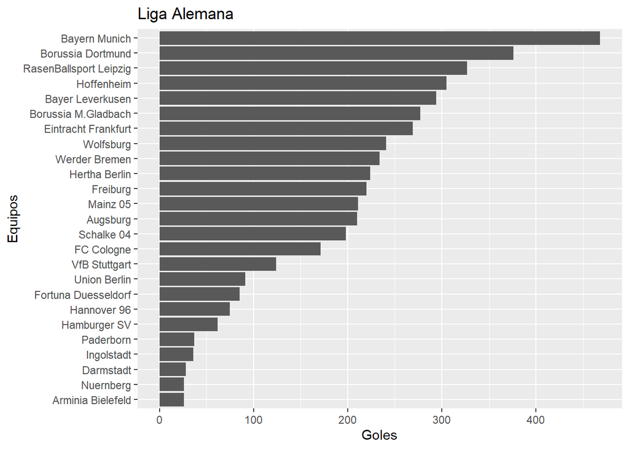

```r
#barchart de graficos de cada de ligaalemana
barchart_lae<-ggplot(data=LigaAlemana_equipo,aes(x=reorder(team,gol_tem), y=gol_tem)) +
  geom_bar(stat="identity")+ coord_flip()+labs(title = "Liga Alemana", x = "Equipos", y = "Goles")
barchart_lae
```

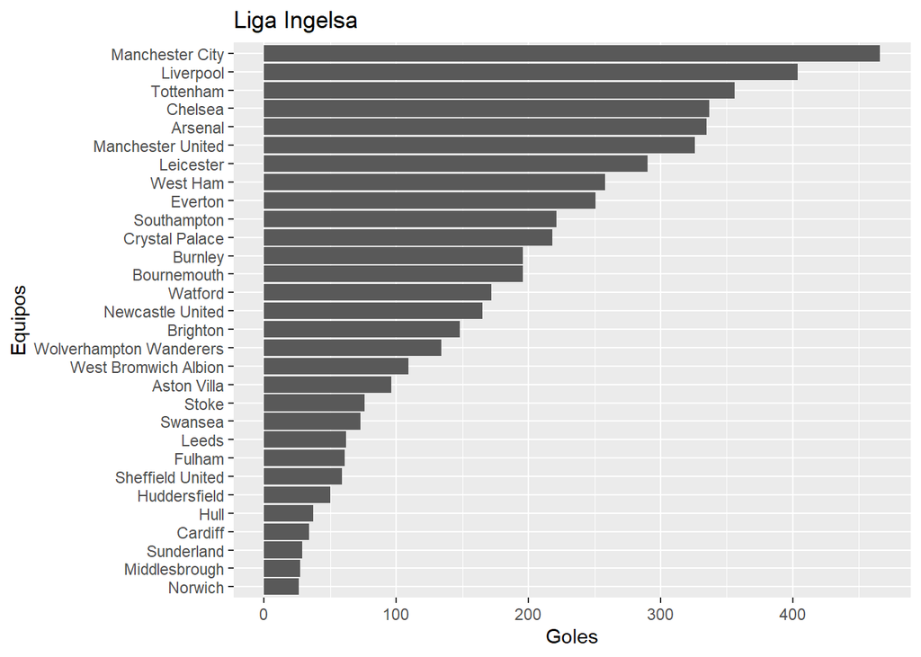

```r
#barchart de graficos de cada de ligainglaterra
barchart_lie<-ggplot(data=LigaInglaterra_equipo,aes(x=reorder(team,gol_tem), y=gol_tem)) +
  geom_bar(stat="identity")+ coord_flip()+labs(title = "Liga Ingelsa", x = "Equipos", y = "Goles")
barchart_lie
```

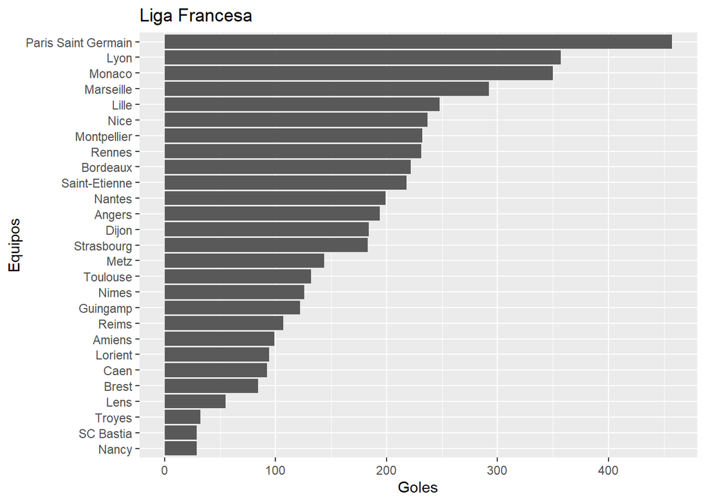

```r
#barchart de graficos de cada de ligafrancia
barchart_lfe<-ggplot(data=LigaFrancia_equipo,aes(x=reorder(team,gol_tem), y=gol_tem)) +
  geom_bar(stat="identity")+ coord_flip()+labs(title = "Liga Francesa", x = "Equipos", y = "Goles")
barchart_lfe
```

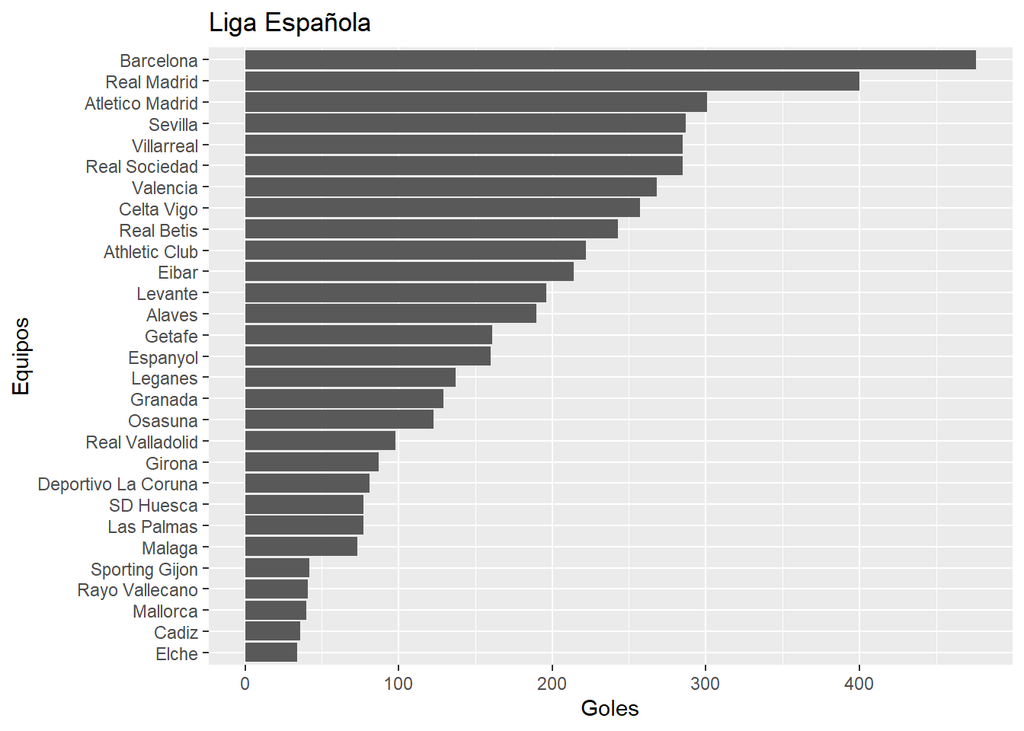

```r
#barchart de graficos de cada de ligaespanola
barchart_lee<-ggplot(data=LigaEspanola_equipo,aes(x=reorder(team,gol_tem), y=gol_tem)) +
  geom_bar(stat="identity")+ coord_flip()+labs(title = "Liga Española", x = "Equipos", y = "Goles")
barchart_lee
```

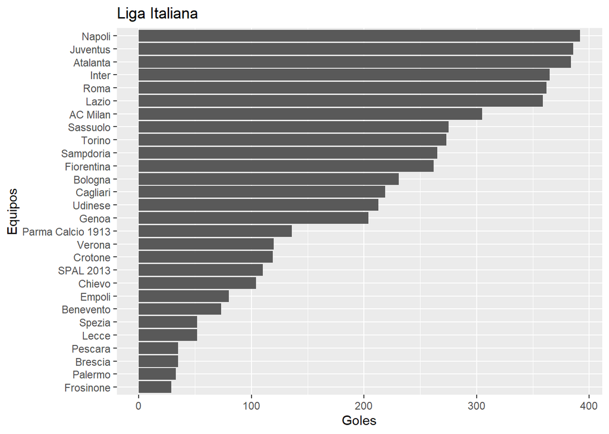

```r
#barchart de graficos de cada de ligaitalia
barchart_lie<-ggplot(data=LigaItalia_equipos,aes(x=reorder(team,gol_tem), y=gol_tem)) +
  geom_bar(stat="identity")+ coord_flip()+labs(title = "Liga Italiana", x = "Equipos", y = "Goles")
barchart_lie
```

# Redimiento de los jugadores claves del 2016- 2020 de cada liga.

Para ello se van a selecionar tres equipos de cada liga y identificar los jugadores mas influyentes.

Tablas de mejores jugadores por liga

```r
head(BestJugadores_LigaAlemana)
```

| player | total_goal | total_disparos | total_owngoals | total_pasesclave | total_asistencias |
| --- | --- | --- | --- | --- | --- |
| Robert Lewandowski | 94 | 225 | 0 | 49 | 8 |
| Andrej Kramaric | 30 | 72 | 0 | 15 | 0 |
| Serge Gnabry | 15 | 29 | 0 | 9 | 0 |

```r
head(BestJugadores_LigaFrancesa)
```

| player | total_goal | total_disparos | total_owngoals | total_pasesclave | total_asistencias |
| --- | --- | --- | --- | --- | --- |
| Kylian Mbappe-Lottin | 55 | 126 | 0 | 41 | 4 |
| Memphis Depay | 35 | 80 | 0 | 46 | 5 |
| Ángel Di María | 12 | 22 | 0 | 17 | 3 |

```r
head(BestJugadores_LigaEspanola)
```

| player | total_goal | total_disparos | total_owngoals | total_pasesclave | total_asistencias |
| --- | --- | --- | --- | --- | --- |
| Lionel Messi | 102 | 283 | 0 | 121 | 20 |
| Luis Suárez | 47 | 92 | 0 | 46 | 11 |
| Antoine Griezmann | 23 | 50 | 0 | 17 | 6 |
| Iago Aspas | 39 | 69 | 0 | 29 | 0 |
| Raúl García | 12 | 28 | 0 | 5 | 0 |

```r
head(BestJugadores_LigaInglesa)
```

| player | total_goal | total_disparos | total_owngoals | total_pasesclave | total_asistencias |
| --- | --- | --- | --- | --- | --- |
| Harry Kane | 63 | 169 | 0 | 37 | 9 |
| Sergio Agüero | 42 | 98 | 0 | 25 | 5 |
| Son Heung-Min | 26 | 51 | 0 | 22 | 5 |
| Jamie Vardy | 35 | 61 | 0 | 17 | 2 |
| Roberto Firmino | 19 | 32 | 0 | 14 | 1 |
| Gabriel Jesus | 16 | 31 | 0 | 12 | 0 |

```r
head(BestJugadores_LigaItaliana)
```

| player | total_goal | total_disparos | total_owngoals | total_pasesclave | total_asistencias |
| --- | --- | --- | --- | --- | --- |
| Dries Mertens | 32 | 71 | 0 | 29 | 4 |
| Andrea Belotti | 35 | 77 | 0 | 23 | 2 |
| Edin Dzeko | 30 | 88 | 0 | 19 | 1 |
| Ciro Immobile | 57 | 122 | 0 | 44 | 5 |
| Alejandro Gomez | 17 | 32 | 0 | 16 | 3 |

Se analiza los tiros de los 3 jugadores con mayor probabilidad de gol (son los jugadores que tienen mas goles en sus respectivas ligas y con varios goles)- para la liga inglesa tenemos como resultado.

En liga Alemana tenemso a Robert Lewandowski, Andrej Kramaric y Serge Gnabry. En la liga Francesa tenemos a Kylian Mbappe-Lottin, Memphis Depay Y Angel Di María. En la liga Espanola tenemos a Lionel Messi, Luis Suárez, Antoine Griezmann,Iago Aspas y Rafaél Garcéda. En la liga Inglesa tenemos a Harry Kane, Sergio Agüero, Son Heung-Min, Jaime Vardy, Roberto Firmino y Gabriel Jesus. En la liga Italiana tenemos a Dries Mertens, Andrea Belotti, Edin Dzeko, Ciro Immobile y Alejandro Gomez.

- Evaluar al jugador- Histograma de mejor rendimiento en un partido de 90 minuto

En la liga Alemana, el jugador que más destaco fue Robert Lewandowski en todas las temporadas y su rendimiento en el campo se puede observar en el siguiente histograma.

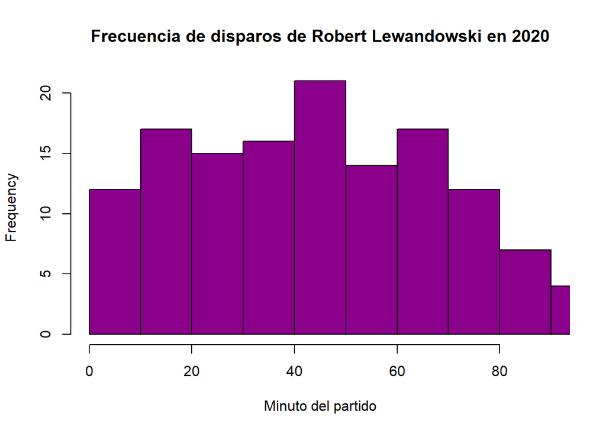

```r
disparos%>% filter(player == "Robert Lewandowski" & season == 2020)-> timegame
disparos%>% filter(player == "Robert Lewandowski" & season == 2018)-> timegame1
disparos%>% filter(player == "Robert Lewandowski" & season == 2016)-> timegame2

hist(timegame$minute, col = "darkmagenta", xlab = "Minuto del partido",xlim = c(0,90), main = "Frecuencia de disparos de Robert Lewandowski en 2020")
```

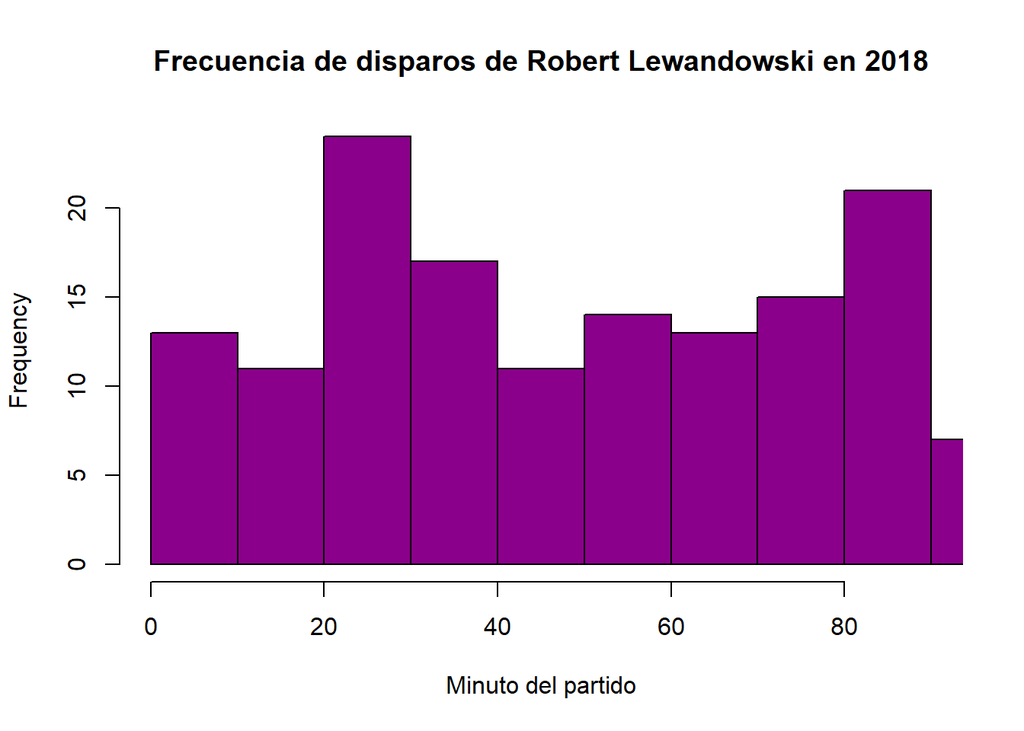

```r
hist(timegame1$minute, col = "darkmagenta", xlab = "Minuto del partido",xlim = c(0,90), main = "Frecuencia de disparos de Robert Lewandowski en 2018")
```

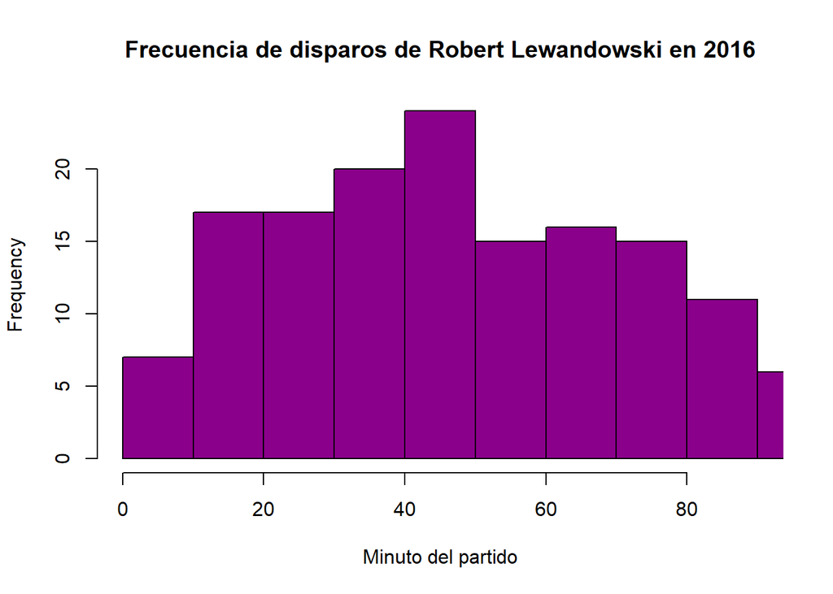

```r
hist(timegame2$minute, col = "darkmagenta", xlab = "Minuto del partido",xlim = c(0,90), main = "Frecuencia de disparos de Robert Lewandowski en 2016")
```

En la liga Francesa, el jugador que más destaco fue “Kylian Mbappe-Lottin” en todas las temporadas – y su rendimiento en el campo se puede observar en el siguiente histograma.

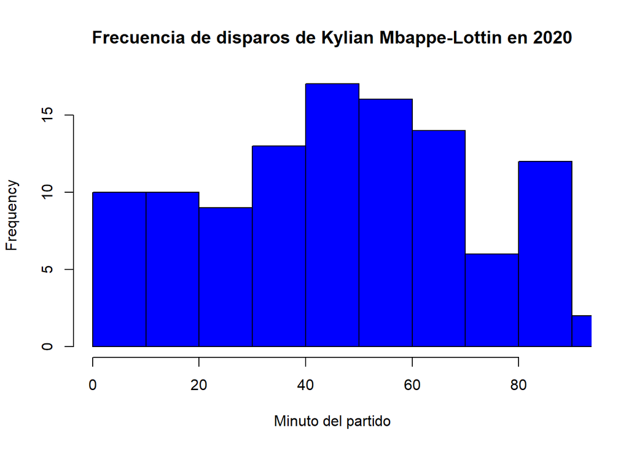

```r
disparos%>% filter(player == "Kylian Mbappe-Lottin" & season == 2020)-> timegame
disparos%>% filter(player == "Kylian Mbappe-Lottin" & season == 2018)-> timegame1
disparos%>% filter(player == "Kylian Mbappe-Lottin" & season == 2016)-> timegame2
hist(timegame$minute, col = "blue", xlab = "Minuto del partido",xlim = c(0,90), main = "Frecuencia de disparos de Kylian Mbappe-Lottin en 2020")
```

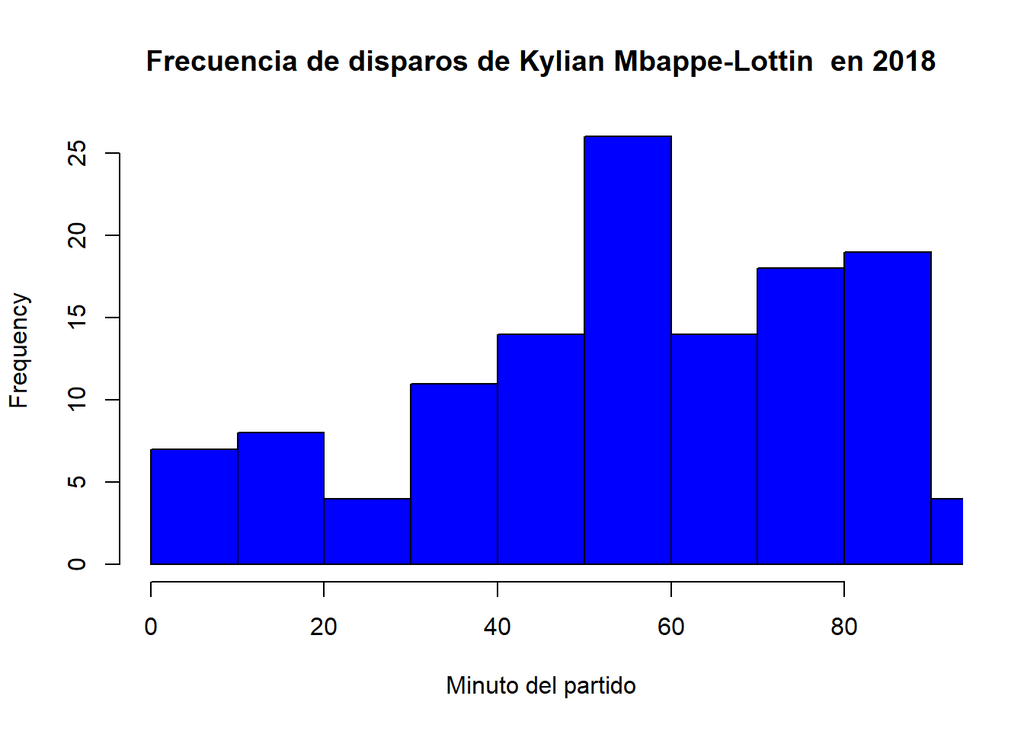

```r
hist(timegame1$minute, col = "blue", xlab = "Minuto del partido",xlim = c(0,90), main = "Frecuencia de disparos de Kylian Mbappe-Lottin  en 2018")
```

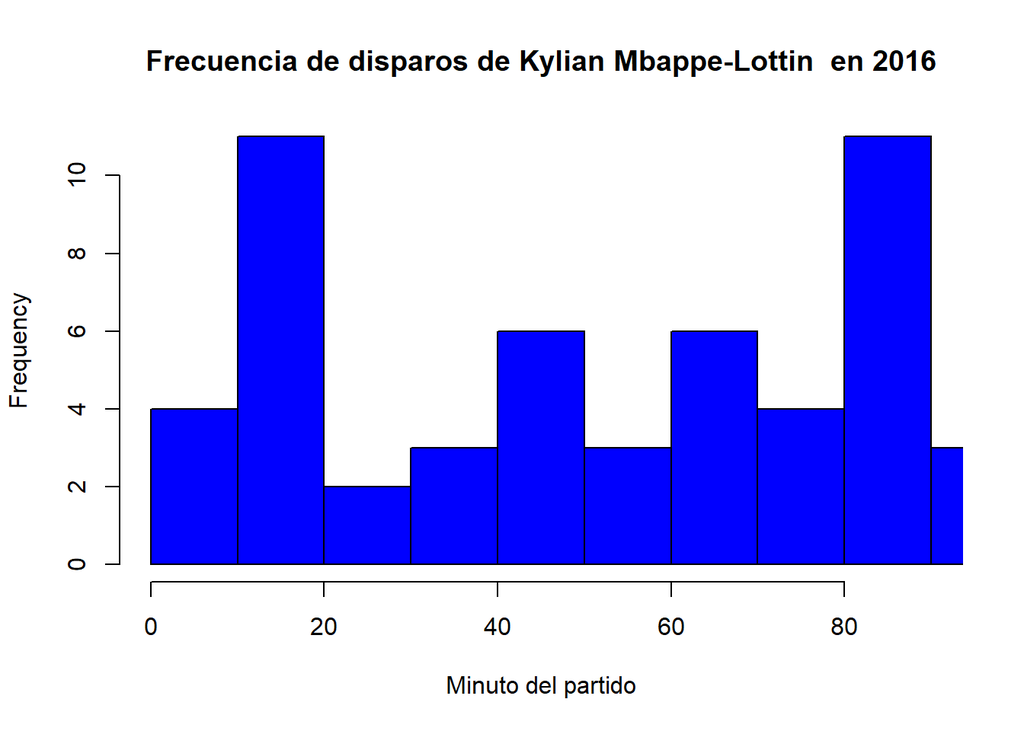

```r
hist(timegame2$minute, col = "blue", xlab = "Minuto del partido",xlim = c(0,90), main = "Frecuencia de disparos de Kylian Mbappe-Lottin  en 2016")
```

Se observa que en la temporada 2020 y 2018, el jugador Kylian Mbappe-Lottin cuenta con una frecuencia de disparos durante el segundo tiempo del partido, mayor a los 45 minutos. A diferencia de la temporada del 2016 que su participación fue bastante irregular y evidenciando diferentes frecuencias de tiros en distintos tiempos durante el partido.

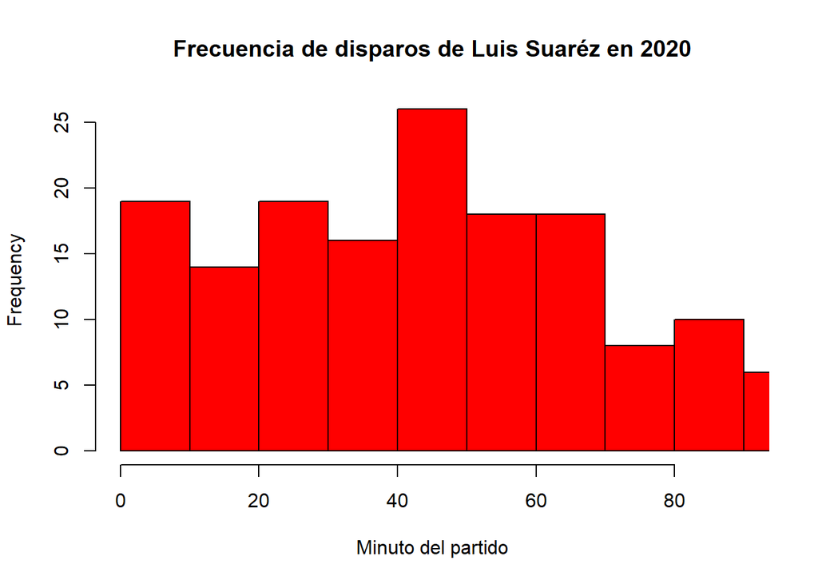

```r
disparos%>% filter(player == "Luis Su\xe1rez" & season == 2020)-> timegame
disparos%>% filter(player == "Luis Su\xe1rez" & season == 2018)-> timegame1
disparos%>% filter(player == "Luis Su\xe1rez" & season == 2016)-> timegame2
hist(timegame$minute, col = "red", xlab = "Minuto del partido",xlim = c(0,90), main = "Frecuencia de disparos de Luis Suaréz en 2020")
```

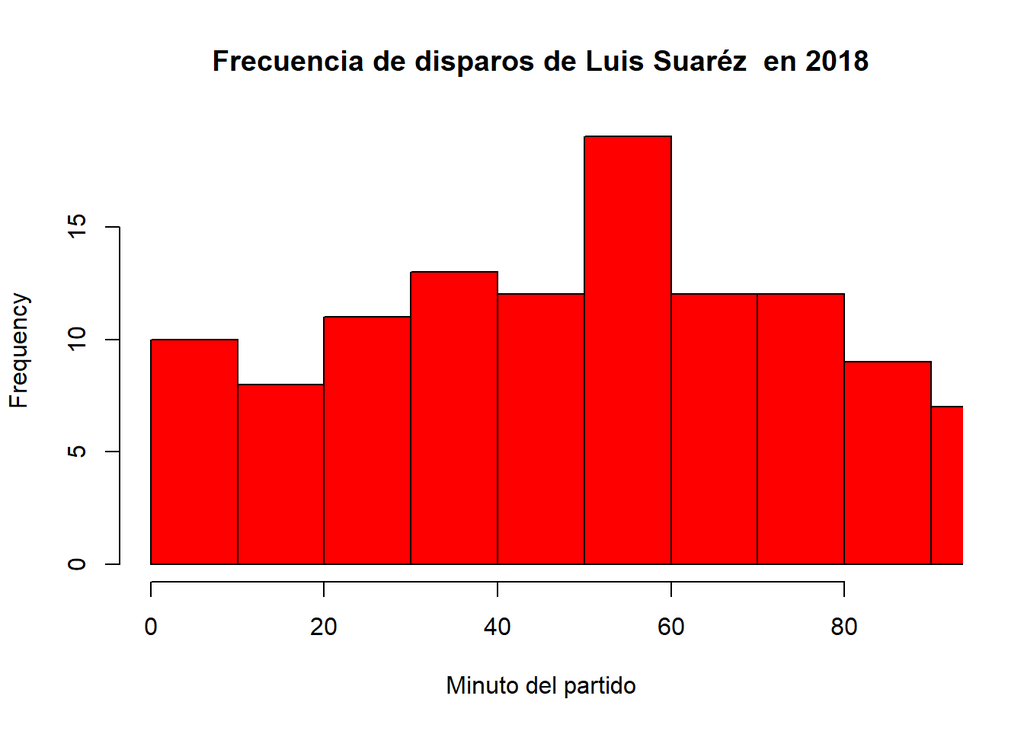

```r
hist(timegame1$minute, col = "red", xlab = "Minuto del partido",xlim = c(0,90), main = "Frecuencia de disparos de Luis Suaréz  en 2018")
```

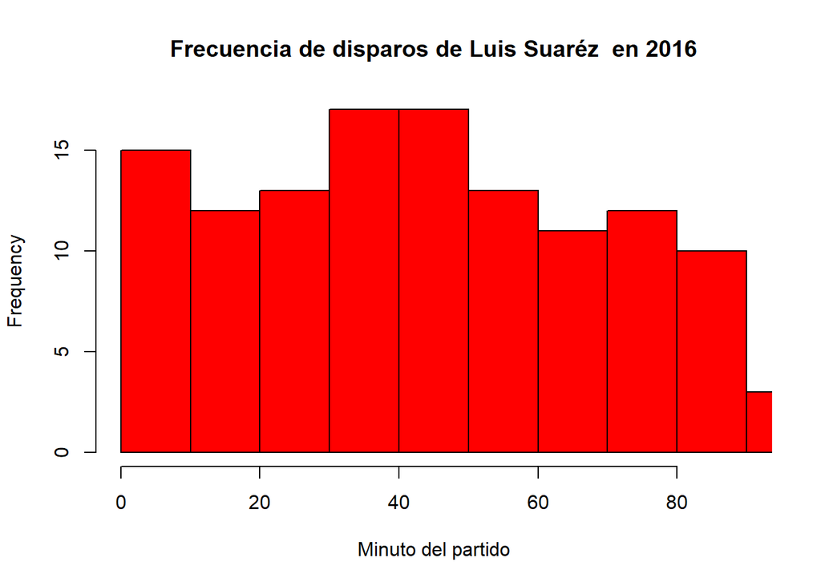

```r
hist(timegame2$minute, col = "red", xlab = "Minuto del partido",xlim = c(0,90), main = "Frecuencia de disparos de Luis Suaréz  en 2016")
```

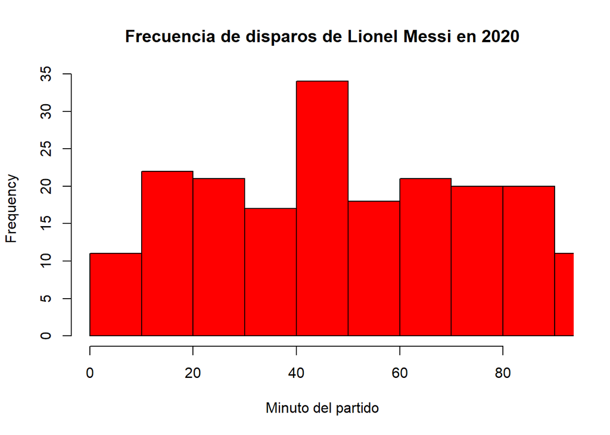

```r
disparos%>% filter(player == "Lionel Messi" & season == 2020)-> timegame
disparos%>% filter(player == "Lionel Messi" & season == 2018)-> timegame1
disparos%>% filter(player == "Lionel Messi" & season == 2016)-> timegame2
hist(timegame$minute, col = "red", xlab = "Minuto del partido",xlim = c(0,90), main = "Frecuencia de disparos de Lionel Messi en 2020")
```

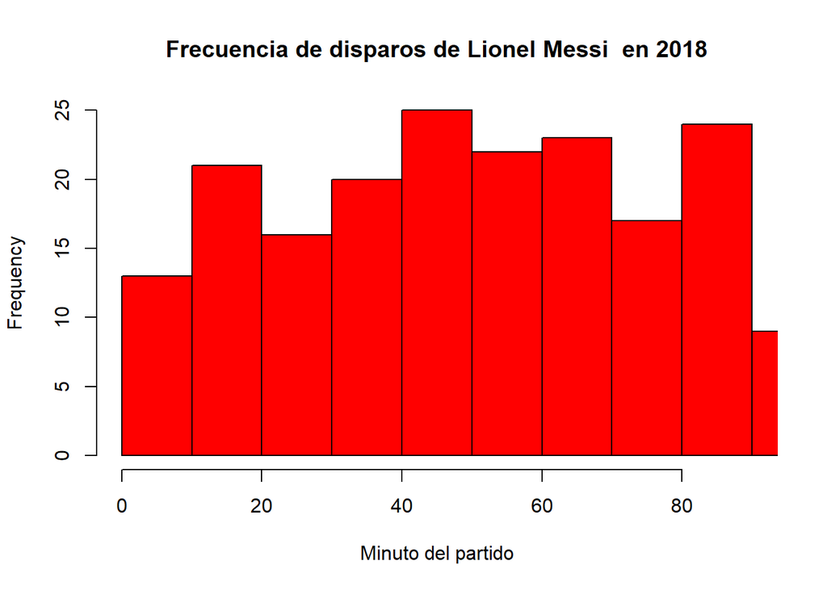

```r
hist(timegame1$minute, col = "red", xlab = "Minuto del partido",xlim = c(0,90), main = "Frecuencia de disparos de Lionel Messi  en 2018")
```

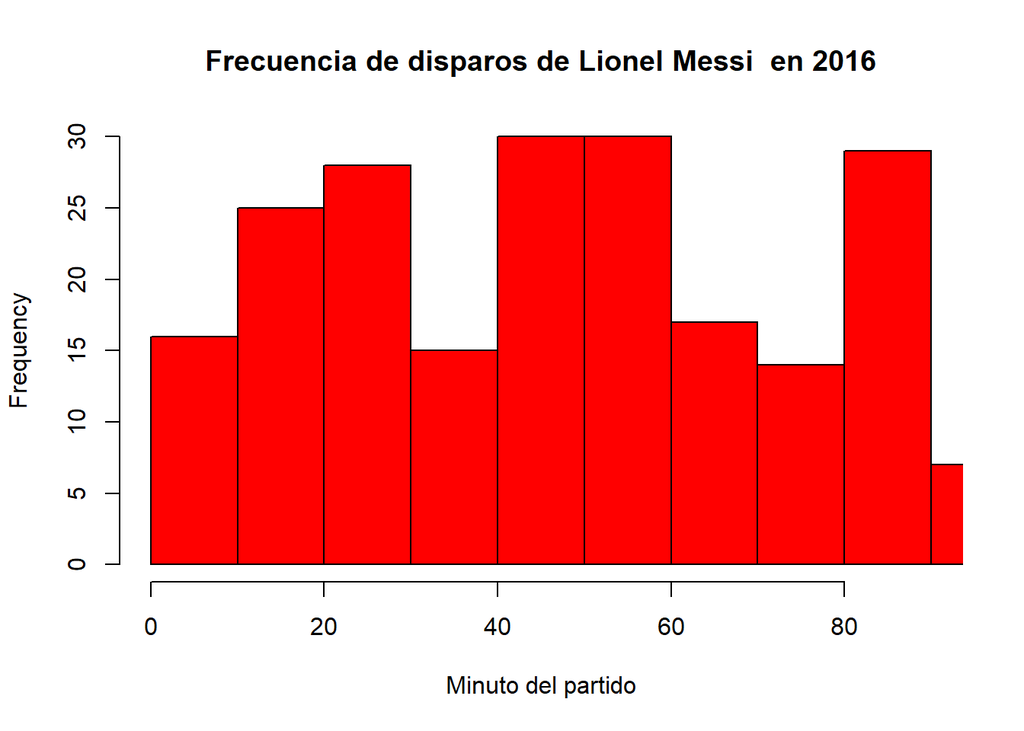

```r
hist(timegame2$minute, col = "red", xlab = "Minuto del partido",xlim = c(0,90), main = "Frecuencia de disparos de Lionel Messi  en 2016")
```

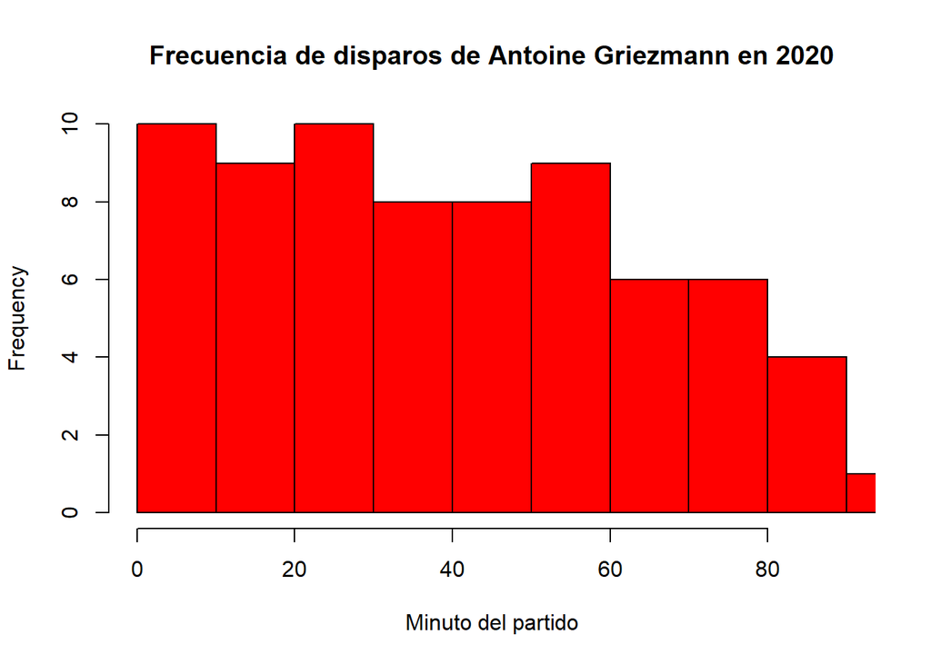

```r
disparos%>% filter(player == "Antoine Griezmann" & season == 2020)-> timegame
disparos%>% filter(player == "Antoine Griezmann" & season == 2018)-> timegame1
disparos%>% filter(player == "Antoine Griezmann" & season == 2016)-> timegame2
hist(timegame$minute, col = "red", xlab = "Minuto del partido",xlim = c(0,90), main = "Frecuencia de disparos de Antoine Griezmann en 2020")
```

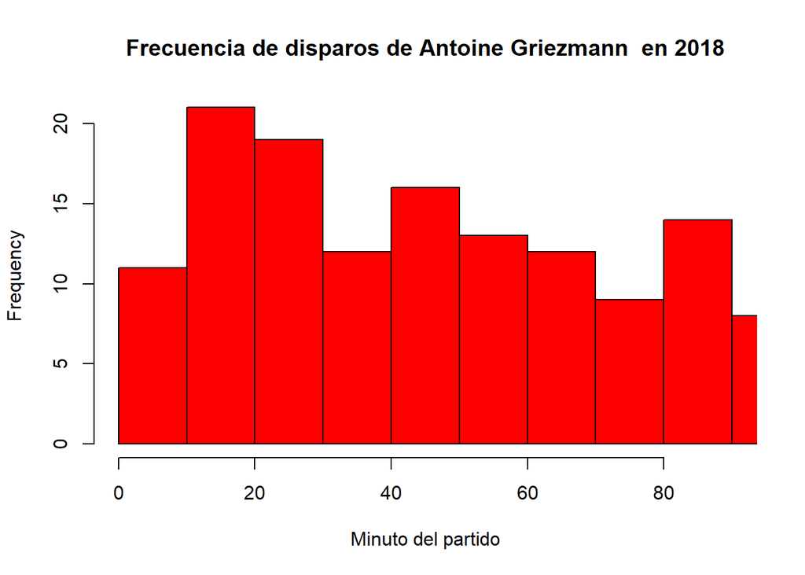

```r
hist(timegame1$minute, col = "red", xlab = "Minuto del partido",xlim = c(0,90), main = "Frecuencia de disparos de Antoine Griezmann  en 2018")
```